# IODS course project

Matti Lassila

# About the project

IODS ([Introduction to Open Data Science](https://blogs.helsinki.fi/thinkopen/welcome-open-data-science/)) is a MOOC offered by University of Helsinki. My goal is to learn new R tips and tricks and to become more organized and productive in data analysis tasks.

Source of this learning diary is available at my [Github repo](https://github.com/mjlassila/IODS-project).

Last updated: 26.11.2018

# Week 2 – Regression and model validation

The following analysis uses dataset (n=166) gathered using *ASSIST: the appproaches and study skills inventory for studets* -survey. For more information regarding the dataset, please see Vehkalahti (2016).

The purpose of the analysis is to explore, whether is it possible to predict student’s test performance using composite variables depicting student’s mental inclination towards studying, namely:

1. positive attitude
2. desire to learn deeply
3. desire to learn quickly without commintment to truly understand the subject matter.
4. strategic mentality torwards studying

These four composite variables were created from the set of 42 variables. Original variables were measured using five-point Likert scale and composite variables were scaled back to the five-point range.

## Exploratory analysis

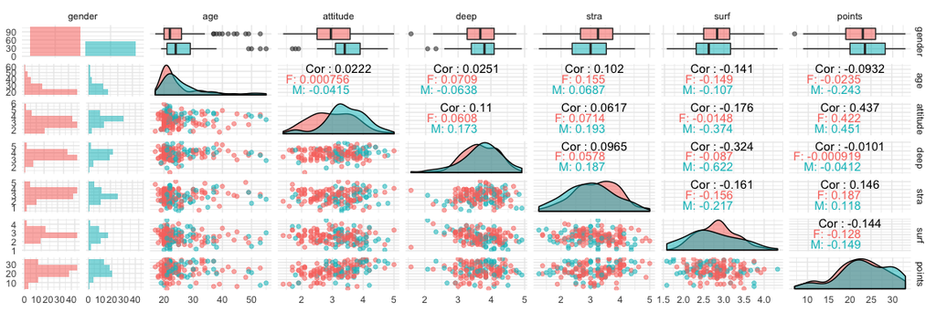

Visual inspection indicates that even though there are slight differences in the attitude and learning approch scores (deep, surface, strategic) between males and females it seems that these differences do not have an effect on median test points. From the figure below we can see that the bulk of the data sits right in the middle of the scale so that there are very few datapoints in the ends of the scales.

### Relationship of gender, attitude and strategic study approach

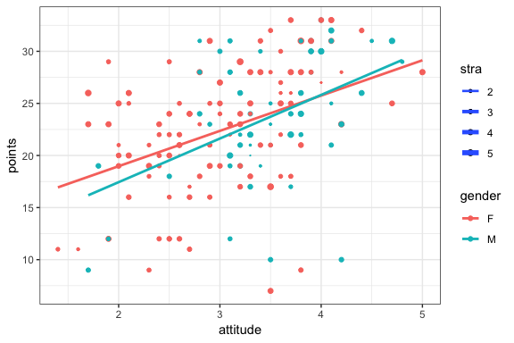

## Regression analysis

In building linear regression models, it is desirable to have high correlations between the prediction covariates and the response variable, but small correlations between the different prediction covariates. Large correlations between prediction variables leads to the [problem of collinearity in linear regression](https://en.wikipedia.org/wiki/Multicollinearity#Consequences_of_multicollinearity), eg. the model might overfit the data.

Based on explorative analysis in Fig 1, three variables were chosen as prediction covariates.

For the first model, the following variables were chosen as predictors.

- attitude (correlation with points, 0.437)
- strategic learning approach (correlation with points, 0.146)
- surface learning approach (correlation with points, -0.144)

Attitude and strategic learning approach do not correlate (0.06), strategic learning and surface learning approach correlate slightly (-0.16) as well as surfarce learning approach and attitude (-0.17).

### Initial model

```r
model_attitude_stra_surf <- lm(
  data = learning2014,
  formula = points ~ attitude + stra + surf )
```

Regression summary

| Predictor | Estimate | Confidence Interval (95%) | t-statistic | p-value |
| --- | --- | --- | --- | --- |
| Intercept | 11.02 | $[3.74$, $18.29]$ | 2.99 | .003 |
| Attitude | 3.40 | $[2.26$, $4.53]$ | 5.91 | < .001 |
| Stra | 0.85 | $[-0.22$, $1.92]$ | 1.58 | .117 |
| Surf | -0.59 | $[-2.17$, $1.00]$ | -0.73 | .466 |

**F Test** summary: (*R<sup>2</sup>*=0.2074, *F*(3,162)=14.13, *p*<1e-05). Adjusted *R<sup>2</sup>* is 0.19.

R<sup>2</sup> is the percentage of the dependent variable variation explained by the linear model. High R-squared values represent smaller differences between the observed data and the fitted values. Having R<sup>2</sup> = 0.2074, our first model explains 20% of the observed variation in student’s test scores.

### Final model

```r
model_attitude_stra <- lm(
  data = learning2014,
  formula = points ~ attitude)
```

Regression summary

| Predictor | Estimate | Confidence Interval (95%) | t-statistic | p-value |
| --- | --- | --- | --- | --- |
| Intercept | 11.64 | $[8.02$, $15.25]$ | 6.36 | < .001 |
| Attitude | 3.53 | $[2.41$, $4.65]$ | 6.21 | < .001 |

For the final model **F Test** summary: (*R<sup>2</sup>*=0.1906, *F*(1,164)=38.61, *p*<1e-05). Adjusted *R<sup>2</sup>* is 0.19.

We see that R<sup>2</sup> stays the same for the revised model. Based on the model coefficients (estimate) and 95% confidence interval for the estiate, we see that for the one unit increase in attitude (predictor) variable, the increase in points is between 2.41 and 4.65, average increase being 3.53 points.

## Regression diagnostics

Regression diagnostics plots help to observe, if the model meets the assumptions of linear regression:

- Linearity of residuals
- Independence of residuals
- Normal distribution of residuals
- Equal variance of residuals

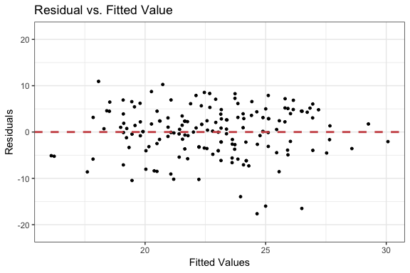

Residuals vs Fitted -plot shows if residuals have non-linear patterns. If the residuals have constant variance of errors, the plot scatters randomly without any distict patterns. We don’t see patterns here, so we can conclude that the variance is constant and the assumption of equal variance of residuals is met.

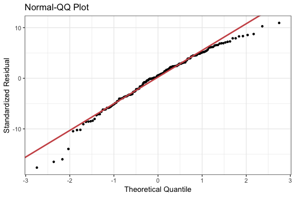

Normal Q-Q -plot shows if residuals are normally distributed. If the residuals deviate from the straight line it is an indication of non-normality. There are few outlying values in both ends of the line but majority of of the points line nicely and therefore we can conclude that the the residuals of the model are normally distributed.

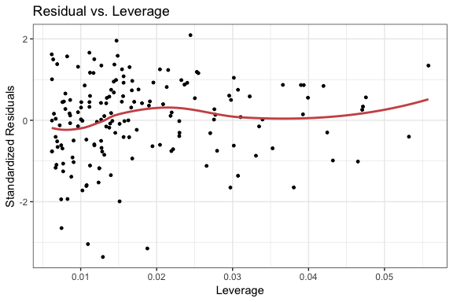

Residual vs. leverage -plot helps to find influential cases. Not all outliers have leverage in linear regression analysis. Values to observe are at the upper right corner or at the lower right corner – they are the ones which can have an effect on regression results. We don’t see outlying values in these critical spots, so we can conclude that there is no influencial individual cases in the data.

## Extra - tweaking the model

Even though we just concluded that there’s no influencial individual cases in the data, we can see from the plots that there are few outlying cases in non-critical spots of the Residual vs. leverage plot. What happens if we exclude them from the data? To do it, we have to single out the cases from the data using Cook’s distance.

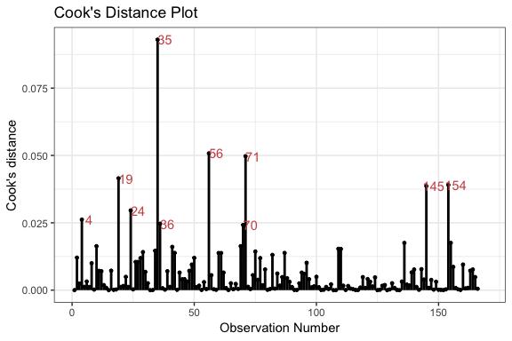

```r
learning2014$id <- 1:dim(learning2014)[1]
model_attitude_stra_excluded <- lm(
  data = learning2014 %>% filter(!id %in% c(35, 56, 71)),
  formula = points ~ attitude)
```

Regression summary

| Predictor | Estimate | Confidence Interval (95%) | t-statistic | p-value |
| --- | --- | --- | --- | --- |
| Intercept | 10.24 | $[6.81$, $13.68]$ | 5.89 | < .001 |
| Attitude | 4.01 | $[2.95$, $5.08]$ | 7.43 | < .001 |

For the model created using data without cases 35, 56, and 71, the **F Test** summary: (*R<sup>2</sup>*=0.2555, *F*(1,161)=55.26, *p*<1e-05). Adjusted *R<sup>2</sup>* is 0.25.

The fit of the model seems to be marginally better when three outlying cases are excluded. Let’s see from the data what kind of cases these are so that we could decide if it is prudent to consider them outliers.

Outlier cases

| Gender | Age | Attitude | Deep | Strategic | Surface | Points |
| --- | --- | --- | --- | --- | --- | --- |
| M | 20 | 4.2 | 4.50 | 3.25 | 1.58 | 10 |
| F | 45 | 3.8 | 3.00 | 3.12 | 3.25 | 9 |
| F | 23 | 1.9 | 4.33 | 2.75 | 2.92 | 29 |

Looking the data, two unfortunate students have scored very low in the test, even though their motivation is strong. It might be that some external cause has affected their test performance as other low-scoring (points <=10) students somewhat differ from these cases. There is also one student whose attitude score is very low but who has achieved high points in tests.

Outlier students

| Gender | Age | Attitude | Deep | Strategic | Surface | Points |
| --- | --- | --- | --- | --- | --- | --- |
| M | 53 | 3.5 | 3.50 | 3.12 | 2.25 | 10 |
| M | 29 | 1.7 | 4.08 | 3.00 | 3.75 | 9 |
| F | 37 | 2.3 | 3.67 | 2.75 | 2.42 | 9 |
| M | 20 | 4.2 | 4.50 | 3.25 | 1.58 | 10 |
| F | 45 | 3.8 | 3.00 | 3.12 | 3.25 | 9 |
| F | 21 | 3.5 | 3.92 | 3.88 | 3.50 | 7 |

# Week 3 – Logistic regression

Our goal if to predict the level of alcohol usage [based on data](https://archive.ics.uci.edu/ml/datasets/student+performance) collected using school reports and questionnaires from two Portugese secondary-level schools. The original dataset (n=382) has the following variables:

- school - student’s school (binary: ‘GP’ - Gabriel Pereira or ‘MS’ - Mousinho da Silveira)
- sex - student’s sex (binary: ‘F’ - female or ‘M’ - male)
- age - student’s age (numeric: from 15 to 22)
- address - student’s home address type (binary: ‘U’ - urban or ‘R’ - rural)
- famsize - family size (binary: ‘LE3’ - less or equal to 3 or ‘GT3’ - greater than 3)
- pstatus - parent’s cohabitation status (binary: ‘T’ - living together or ‘A’ - apart)
- medu - mother’s education (numeric: 0 - none, 1 - primary education (4th grade), 2 - 5th to 9th grade, 3 - secondary education or 4 - higher education)
- fedu - father’s education (numeric: 0 - none, 1 - primary education (4th grade), 2 - 5th to 9th grade, 3 - secondary education or 4 - higher education)
- mjob - mother’s job (nominal: ‘teacher’, ‘health’ care related, civil ‘services’ (e.g. administrative or police), ‘at_home’ or ‘other’)
- fjob - father’s job (nominal: ‘teacher’, ‘health’ care related, civil ‘services’ (e.g. administrative or police), ‘at_home’ or ‘other’)
- reason - reason to choose this school (nominal: close to ‘home’, school ‘reputation’, ‘course’ preference or ‘other’)
- guardian - student’s guardian (nominal: ‘mother’, ‘father’ or ‘other’)
- traveltime - home to school travel time (numeric: 1 - <15 min., 2 - 15 to 30 min., 3 - 30 min. to 1 hour, or 4 - >1 hour)
- studytime - weekly study time (numeric: 1 - <2 hours, 2 - 2 to 5 hours, 3 - 5 to 10 hours, or 4 - >10 hours)
- failures - number of past class failures (numeric: n if 1<=n<3, else 4)
- schoolsup - extra educational support (binary: yes or no)
- famsup - family educational support (binary: yes or no)
- paid - extra paid classes within the course subject (Math or Portuguese) (binary: yes or no)
- activities - extra-curricular activities (binary: yes or no)
- nursery - attended nursery school (binary: yes or no)
- higher - wants to take higher education (binary: yes or no)
- internet - Internet access at home (binary: yes or no)
- romantic - with a romantic relationship (binary: yes or no)
- famrel - quality of family relationships (numeric: from 1 - very bad to 5 - excellent)
- freetime - free time after school (numeric: from 1 - very low to 5 - very high)
- goout - going out with friends (numeric: from 1 - very low to 5 - very high)
- dalc - workday alcohol consumption (numeric: from 1 - very low to 5 - very high)
- walc - weekend alcohol consumption (numeric: from 1 - very low to 5 - very high)
- health - current health status (numeric: from 1 - very bad to 5 - very good)
- absences - number of school absences (numeric: from 0 to 93) *
- g1 - first period grade (numeric: from 0 to 20)
- g2 - second period grade (numeric: from 0 to 20)
- g3 - final grade (numeric: from 0 to 20, output target)

In addition, the following variables were created for the analysis

- alc_use - mean of workday and weekend alcohol consumption (numeric)
- high_use - binary variable, TRUE if alc_use > 2

Numerical abseentism score was transformed to five-class categorical variable (0–1, 2, 3–4, 5–7, >8) for the purpose of the analysis.

Because there are as many as 27 variables in the final dataset, choosing interesting and hopefully fruitful variables just by guessing is not likely to succeed. Therefore, let’s use [Goodman-Kruskal tau](https://cran.r-project.org/web/packages/GoodmanKruskal/vignettes/GoodmanKruskal.html) to explore associations between variables in the dataset.

We have to use tau for this, instead of familiar Pearson correlation, as it doesn’t give us useful results when variables are not continuous. It should be noted, that even though many of the variables in the dataset are numerical (such as studytime, frequency of going out and amount of abseentism), according to the dataset description they are actually ordered categorical variables and therefore using tau to study association is sensible choice.

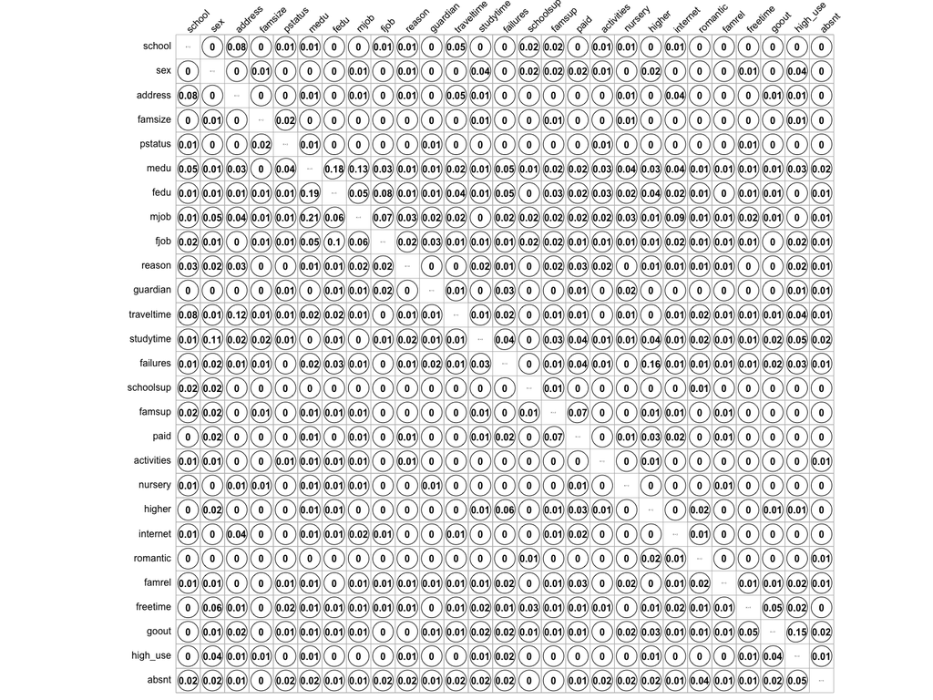

It can be seen from the initial Goodman-Kruskal tau-matrix that the association between heavy drinking and other variables is strongest between frenquency of going out with friends, amount of abseentism, time dedicated for studying and gender. It should be noted that the association with gender is as strong as with freetime, but intuitively if feels more reasonable study the association of gender to the drinking habits than the amount of free time.

Based on observed associations in the data and personal experience, a reasonable initial hypothesis would be:

> Going often out with friends and is correlated with high drinking. Gender doesn’t make signinificant difference, even tough male students tend to drink more. Time dedicaded to studies is inversely associated with high alcohol use but igh abseentism has no significant association with heavy drinking

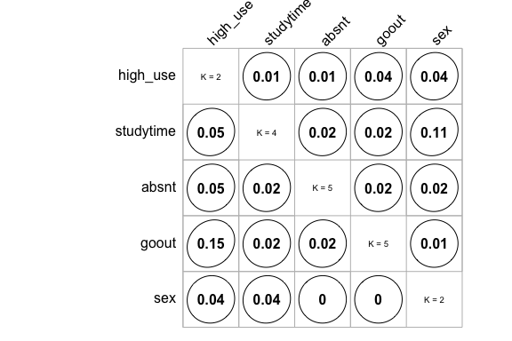

Next we’ll observe the relationship of variables using mosaic plots, which allow us to explore the data in multiple dimensions at the same time.

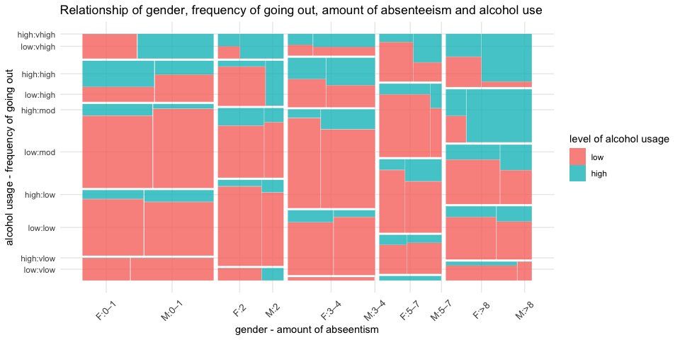

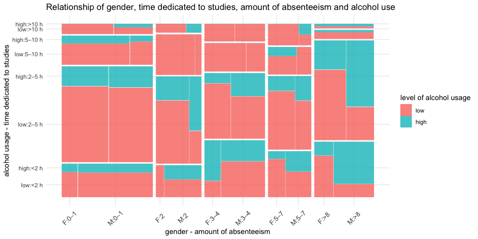

Looking the plots it seems that our initial hypothesis was somewhat inaccurate. Differences between genders are at least visually observing large. Going often out with friends is indeed associated with high level of alcohol use, especially when the abseentism is common (top right corner of the first plot). On the other hand, the size of this group is not very large, so this three-way association might not be strong. Time dedicated to studies is inversely correlated with high alcohol use and amount of abseentism (top right corner).

### Modeling

#### Initial model

```
##
## Call:
## glm(formula = high_use ~ goout + sex + absnt + studytime, family = "binomial",
##     data = alc)
##
## Deviance Residuals:
##     Min       1Q   Median       3Q      Max
## -2.0011  -0.7391  -0.4707   0.7279   2.6452
##
## Coefficients:
##                 Estimate Std. Error z value Pr(>|z|)
## (Intercept)     -2.34971    0.69745  -3.369 0.000754 ***
## gooutlow         0.39022    0.70228   0.556 0.578449
## gooutmod         0.63488    0.69198   0.917 0.358895
## goouthigh        2.16469    0.69593   3.110 0.001868 **
## gooutvhigh       2.38300    0.71257   3.344 0.000825 ***
## sexM             0.76948    0.27549   2.793 0.005220 **
## absnt2           0.41615    0.41509   1.003 0.316074
## absnt3–4         0.03195    0.38525   0.083 0.933897
## absnt5–7        -0.20080    0.42637  -0.471 0.637679
## absnt>8          1.05424    0.36589   2.881 0.003961 **
## studytime2–5 h  -0.44563    0.30751  -1.449 0.147302
## studytime5–10 h -0.91718    0.48515  -1.891 0.058689 .
## studytime>10 h  -1.01073    0.62811  -1.609 0.107583
## ---
## Signif. codes:  0 '***' 0.001 '**' 0.01 '*' 0.05 '.' 0.1 ' ' 1
##
## (Dispersion parameter for binomial family taken to be 1)
##
##     Null deviance: 465.68  on 381  degrees of freedom
## Residual deviance: 374.51  on 369  degrees of freedom
## AIC: 400.51
##
## Number of Fisher Scoring iterations: 4
```

Looking the odds ratios of the model, it can be stated that being male increases the odds of high alcohol usage over 2 times compared to females, going out frequently or very frequently increses the odds 8-10 times compared to the students who go out very little or not at all. High abseentism also increases the odds of high alcohol consumption 2.87 times compared to the studets who are not in the habit of abseentism.

These model-based observations align pretty well on the conclusions which were made based on the initial visual exploration of the data.

| Predictor | Estimate | CI (95%) | t | p-value | Odds ratio |
| --- | --- | --- | --- | --- | --- |
| gooutmod | 0.63 | $[-0.61$, $2.18]$ | 0.92 | .359 | 1.89 |
| goouthigh | 2.16 | $[0.92$, $3.72]$ | 3.11 | .002 | 8.71 |
| gooutvhigh | 2.38 | $[1.10$, $3.97]$ | 3.34 | .001 | 10.84 |
| sexm | 0.77 | $[0.23$, $1.32]$ | 2.79 | .005 | 2.16 |
| abseentism>8 | 1.05 | $[0.34$, $1.78]$ | 2.88 | .004 | 2.87 |
| studytime5–10 h | -0.92 | $[-1.92$, $0.00]$ | -1.89 | .059 | 0.40 |

#### Final model

```r
alc_glm_second <- glm(
  formula = high_use ~ goout + sex + absnt,
  family = "binomial",
  data = alc)
summary(alc_glm_second)
```

```
##
## Call:
## glm(formula = high_use ~ goout + sex + absnt, family = "binomial",
##     data = alc)
##
## Deviance Residuals:
##     Min       1Q   Median       3Q      Max
## -1.9016  -0.7054  -0.4885   0.6704   2.4222
##
## Coefficients:
##             Estimate Std. Error z value Pr(>|z|)
## (Intercept) -2.72000    0.67394  -4.036 5.44e-05 ***
## gooutlow     0.20910    0.69706   0.300 0.764194
## gooutmod     0.42097    0.68290   0.616 0.537598
## goouthigh    1.99006    0.68527   2.904 0.003684 **
## gooutvhigh   2.24070    0.70637   3.172 0.001513 **
## sexM         0.94468    0.26159   3.611 0.000305 ***
## absnt2       0.44525    0.41055   1.085 0.278133
## absnt3–4     0.09012    0.37728   0.239 0.811208
## absnt5–7    -0.15888    0.41776  -0.380 0.703710
## absnt>8      1.16366    0.36153   3.219 0.001288 **
## ---
## Signif. codes:  0 '***' 0.001 '**' 0.01 '*' 0.05 '.' 0.1 ' ' 1
##
## (Dispersion parameter for binomial family taken to be 1)
##
##     Null deviance: 465.68  on 381  degrees of freedom
## Residual deviance: 379.98  on 372  degrees of freedom
## AIC: 399.98
##
## Number of Fisher Scoring iterations: 4
```

Predicted vs. actual alcohol use (counts)

|  | predicted low | predicted high |
| --- | --- | --- |
| low | 245 | 23 |
| high | 58 | 56 |

Predicted vs. actual alcohol use (%)

|  | predicted low | predicted high | Sum |
| --- | --- | --- | --- |
| low | 64.1 | 6.0 | 70.1 |
| high | 15.2 | 14.7 | 29.9 |
| Sum | 79.3 | 20.7 | 100.0 |

Crosstables indicate that model tends to overpredict the proportion of students who are low-drinkers (actual) and underpredict the proportion of high-drinking students.

| Predictor | Estimate | CI (95%) | t | p-value | Odds ratio |
| --- | --- | --- | --- | --- | --- |
| goouthigh | 1.99 | $[0.76$, $3.53]$ | 2.90 | .004 | 7.32 |
| gooutvhigh | 2.24 | $[0.97$, $3.81]$ | 3.17 | .002 | 9.40 |
| sexm | 0.94 | $[0.44$, $1.47]$ | 3.61 | < .001 | 2.57 |
| abseentism>8 | 1.16 | $[0.46$, $1.88]$ | 3.22 | .001 | 3.20 |

For the final model, the odds ratio of high alcohol use increasse 2.57 times when the student is male, 3.20 times when number of school absensces is higher than 8 (compared to zero to one absences), and 7.32-9.40 times when the student goes out with friends frequently or very frequently, compared to going out very little or no at all.

## Performance comparison

```r
loss_func <- function(class, prob) {
  n_wrong <- abs(class - prob) > 0.5
  mean(n_wrong)
}

training_error <- loss_func(class = alc$hu, prob = alc$predict_high_use)
training_error_simple <- loss_func(class = alc_simple$hu, prob = alc_simple$predict_high_use)
```

The model has 0.212 training error. Error for initial model is 0.204 so it seems that keeping studytime predictor in the model would have been useful.

```r
library(boot)
cv <- cv.glm(data = alc, cost = loss_func, glmfit = alc_glm_second, K = 10)
cv_simple <- cv.glm(data = alc_simple, cost = loss_func, glmfit = alc_glm_first, K = 10)
```

[output not shown]

# Week 4 – Clustering

Our goal for the fourth week is to explore census data collected in 1970 from the Boston metropolitan area. Our first step is to try to predicting the crime rate in the Boston area using plethora of predictor variables. Finally we’ll see what kind of clusters we can find from the dataset when running *k-means* clustering algorithm over the data.

The dataset is discussed more deeply in Harrison, D. and Rubinfeld, D.L. (1978) Hedonic prices and the demand for clean air. *Journal of Environmental Economics and Management* 5, 81–102 ([PDF](https://www.researchgate.net/publication/238676322_Hedonic_prices_and_the_demand_for_clean_air))

```
## Skim summary statistics
##  n obs: 506
##  n variables: 14
##
## ── Variable type:integer ────────────
##  variable missing complete   n  mean   sd p0 p25 p50 p75 p100     hist
##      chas       0      506 506 0.069 0.25  0   0   0   0    1 ▇▁▁▁▁▁▁▁
##       rad       0      506 506 9.55  8.71  1   4   5  24   24 ▂▇▁▁▁▁▁▅
##
## ── Variable type:numeric ────────────
##  variable missing complete   n   mean     sd       p0     p25    p50
##       age       0      506 506  68.57  28.15   2.9     45.02   77.5
##     black       0      506 506 356.67  91.29   0.32   375.38  391.44
##      crim       0      506 506   3.61   8.6    0.0063   0.082   0.26
##       dis       0      506 506   3.8    2.11   1.13     2.1     3.21
##     indus       0      506 506  11.14   6.86   0.46     5.19    9.69
##     lstat       0      506 506  12.65   7.14   1.73     6.95   11.36
##      medv       0      506 506  22.53   9.2    5       17.02   21.2
##       nox       0      506 506   0.55   0.12   0.39     0.45    0.54
##   ptratio       0      506 506  18.46   2.16  12.6     17.4    19.05
##        rm       0      506 506   6.28   0.7    3.56     5.89    6.21
##       tax       0      506 506 408.24 168.54 187      279     330
##        zn       0      506 506  11.36  23.32   0        0       0
##     p75   p100     hist
##   94.07 100    ▁▂▂▂▂▂▃▇
##  396.23 396.9  ▁▁▁▁▁▁▁▇
##    3.68  88.98 ▇▁▁▁▁▁▁▁
##    5.19  12.13 ▇▅▃▃▂▁▁▁
##   18.1   27.74 ▃▆▅▁▁▇▁▁
##   16.96  37.97 ▆▇▆▅▂▁▁▁
##   25     50    ▂▅▇▆▂▂▁▁
##    0.62   0.87 ▇▆▇▆▃▅▁▁
##   20.2   22    ▁▂▂▂▅▅▇▃
##    6.62   8.78 ▁▁▂▇▇▂▁▁
##  666    711    ▃▇▂▅▁▁▁▆
##   12.5  100    ▇▁▁▁▁▁▁▁
```

The dataset has 506 observations and 14 variables. My guess is that observations correspond to cencus districts, eg. subportions of town, as it is very unlikely that Boston metropolitan has over 500 towns.

[output not shown]

Renaming variables makes it easier in later steps to discuss our findings.

```r
boston_column_names <- c(
  'per_capita_crime',
  'proportion_big_lots',
  'proportion_industry',
  'river_near',
  'nox_concentration',
  'rooms_per_dwelling',
  'proportion_old_houses',
  'mean_distance_to_centers',
  'highway_access',
  'tax_value',
  'pupil_teacher_ratio',
  'proportion_blacks',
  'lower_status',
  'house_median_value'
)

names(boston) <- boston_column_names
```

## Exploring the data

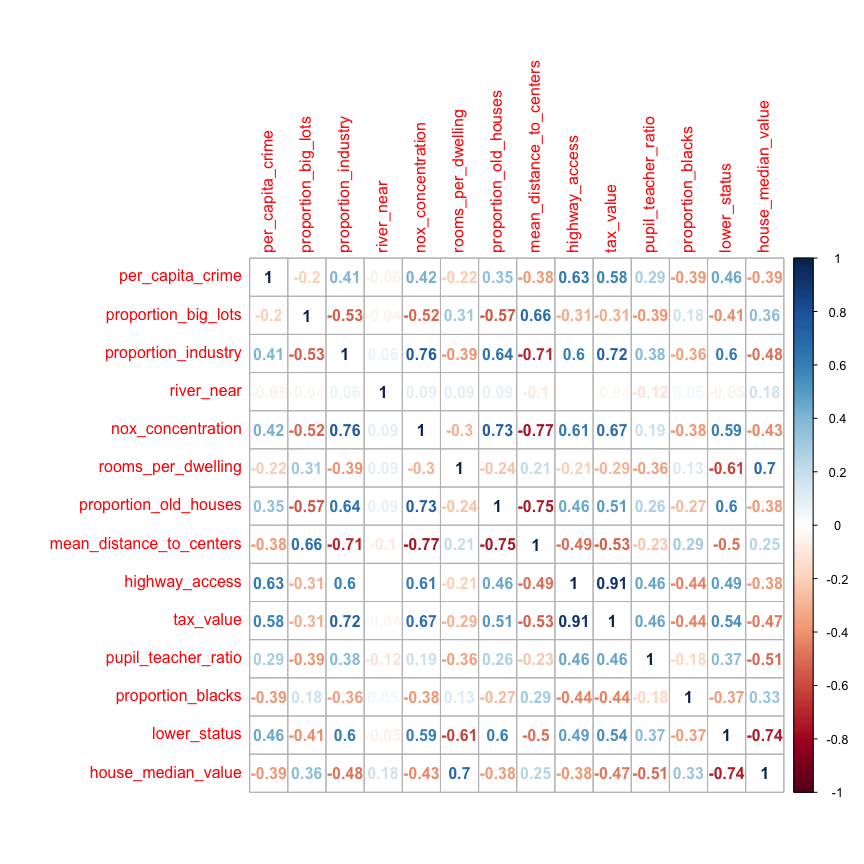

Let’s have a closer look of variables which have higehst correlation with criminality.

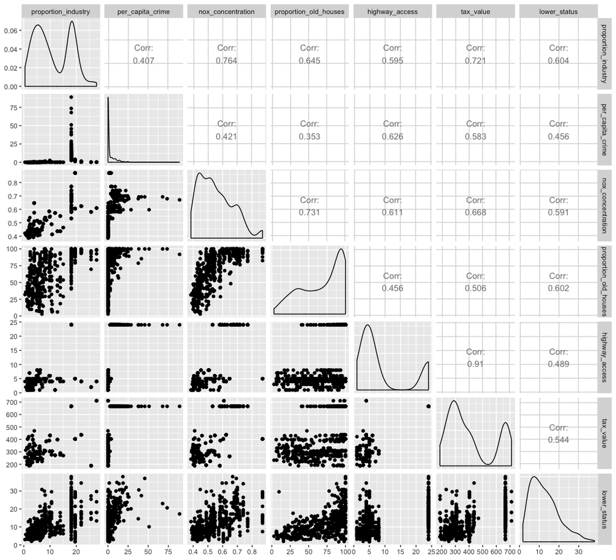

Looking the data my intuition is that low-status (likely working-class) housing near highways and industrial areas are more prone to have a higher crime rate.

```r
# Create a categorical variable of the crime rate in the
# Boston dataset (from the scaled crime rate). Use the quantiles as the break
# points in the categorical variable. Drop the old crime rate variable from the
# dataset. Divide the dataset to train and test sets, so that 80% of the data
# belongs to the train set. (0-2 points)

boston_scaled %<>%
    mutate(
      crime_cat = quantcut(
        per_capita_crime,
        labels = c("very low","low","high","very high")
        )
      ) %>% select(-per_capita_crime)


# Let's use  Caret to create training dataset and make sure that
# the overall class distribution is preserved
# eg. the random sampling occurs within each class

rows_to_train <- caret::createDataPartition(boston_scaled$crime_cat, p = .8,
                                  list = FALSE,
                                  times = 1)

boston_training <- boston_scaled[rows_to_train,]
boston_test <- boston_scaled[-rows_to_train,]
```

## Linear discriminant analysis and prediction

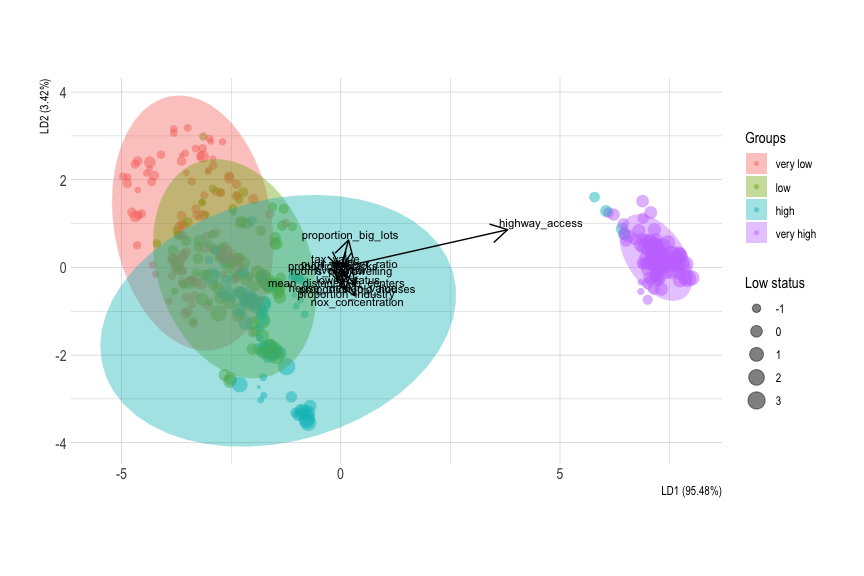

Predicted (cols) vs. actual (rows) crime rate in Boston

|  | very low | low | high | very high |
| --- | --- | --- | --- | --- |
| very low | 13 | 10 | 2 | 0 |
| low | 8 | 15 | 2 | 0 |
| high | 1 | 11 | 11 | 2 |
| very high | 0 | 0 | 1 | 24 |

## K-means clustering

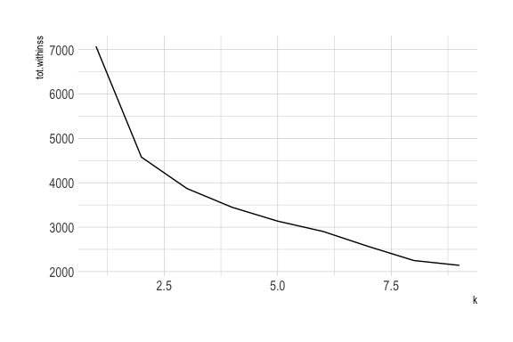

Plot represents the variance within the clusters. It decreases as k increases, but one can notice a bend (or “elbow”) at ~2. This bend indicates that additional clusters beyond this point have only little value. So, let’s fit k-means clustering with k=2.

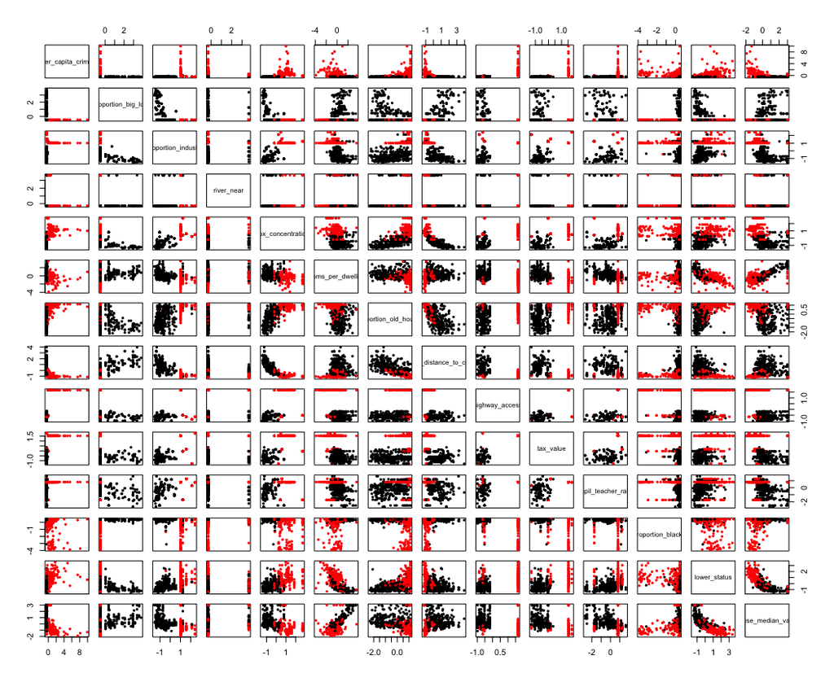

Looking the plots, our two clusters correspond pretty nicely to our intuition of crime-prone neighbourhoods residing near high-pollution industrial areas and highways. More affluent cluster 1 (colour black) has less criminality. Cluster 2 has more pollution, is located near to highways, has factories nearby and has more criminality.

Affulent and less affulent neighbourhoods of Boston metropolitan area

| cluster | proportion_industry | per_capita_crime | nox_concentration | proportion_old_houses | highway_access | tax_value | lower_status |
| --- | --- | --- | --- | --- | --- | --- | --- |
| 1 | -0.6146857 | -0.3894158 | -0.5823397 | -0.4331555 | -0.5828749 | -0.6291043 | -0.4530491 |
| 2 | 1.1425514 | 0.7238295 | 1.0824279 | 0.8051309 | 1.0834228 | 1.1693521 | 0.8421083 |

## References

Vehkalahti, Kimmo. 2016. “The Relationship Between Learning Approaches and Students’ Achievements in an Introductory Statistics Course in Finland.” In *Proceedings of the 60th ISI World Statistics Congress of the International Statistical Institute, ISI2015*, 68–73. http://hdl.handle.net/10138/163015.